# Projekt 2

Tarashkevich Pavel, Grudkowski Artur

2 06 2021

# Zadanie 1

Analizowane województwa:

- Mazowieckie
- Warmińsko-mazurskie
- Dolnośląskie
- Podkarpackie
- Podlaskie
- Śląskie
- Świętokrzyskie

Dane dotyczące populacji województw: https://stat.gov.pl/obszary-tematyczne/ludnosc/ludnosc/powierzchnia-i-ludnosc-w-przekroju-terytorialnym-w-2020-roku,7,17.html

Dane dotyczące liczby szczepień: http://bit.ly/covid19-poland

Dane na dzień **08.06.2021**

```r
data_1 <- data.frame(voivodeship=c('Mazowieckie',
                                   'Warmińsko-mazurskie',
                                   'Dolnośląskie',
                                   'Podkarpackie',
                                   'Podlaskie',
                                   'Śląskie',
                                   'Świętokrzyskie'),
                    vaccinated=as.integer(c(3460137, 737079, 1828954, 1066268, 699749, 2693489, 627930)),
                    deaths=as.integer(c(9332, 2980, 4851, 4423, 2127, 9310, 2521)),
                    confirmed_cases=as.integer(c(396040, 121772, 212832, 126389, 69798, 362023, 72899)),
                    population=as.integer(c(5423168, 1422737, 2900163, 2127164, 1178353, 4517635, 1233961)))
```

| Województwo | Ilosść zaszczepionych osób | Liczba zgonów | Liczba zakażonych | Populacja |
| --- | --- | --- | --- | --- |
| Mazowieckie | 3460137 | 9332 | 396040 | 5423168 |
| Warmińsko-mazurskie | 737079 | 2980 | 121772 | 1422737 |
| Dolnośląskie | 1828954 | 4851 | 212832 | 2900163 |
| Podkarpackie | 1066268 | 4423 | 126389 | 2127164 |
| Podlaskie | 699749 | 2127 | 69798 | 1178353 |
| Śląskie | 2693489 | 9310 | 362023 | 4517635 |
| Świętokrzyskie | 627930 | 2521 | 72899 | 1233961 |

## a) Sprawdz, czy proces szczepien przeciw SARS-CoV-2 przebiega równie szybko we wszystkich województwach, tzn. czy liczba szczepien jest proporcjonalna do populacji tych wojewdództw.

W celu sprawdzenia czy proces szczepień przciw SARS-CoV-2 przebiega równie szybko wewszystkich wojewodxtwach należy przeprowadzić test określający zgodność rozkładów tj. sprawdzenie tego czy dane dotyczące liczby wykonanych szczepień pochodzą z tego samego rozkłądu co wielkości populacji. Test, który odpowiada za określenie zgodności rozkładów nosi nazwę testu zgodności rozkładu *chi-kwadrat*. Możliwość wykonania takiego testu dostarcza metoda *chisq.test* z ustawionymi odpowiednimi parametrami.

**Hipoteza zerowa**: liczba szczepień przeciw SARS-CoV-2 jest proporcjonalna do populacji tych województw.

### Wizualizacja dancy

Poniżej zwizualizowano wielkości województw oraz stosunek liczby szczepień do wielkości populacji dla każdego z województw. Ma to na celu poglądowe przedstawienie zależności, które będą sprawdzane przy pomocy testu zgodności rozkładu *chi-kwadrat*.

#### Wielkośc populacji województw

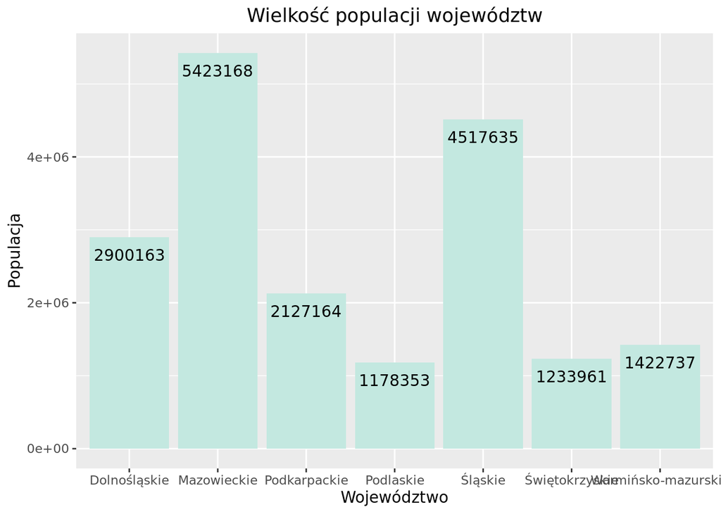

#### Stosunek liczby szczepień do populacji dla województw

```r
data_1['vacination_factor'] = data_1$vaccinated / data_1$population
```

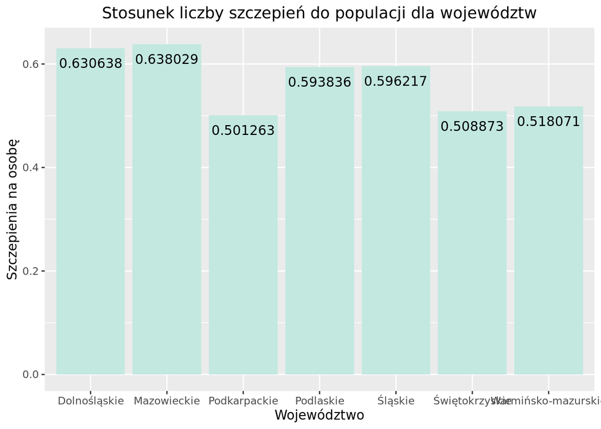

### Test zgodności rozkładu *chi-kwadrat*

```r
population_probabilities <- data_1$population / sum(data_1$population)

test_result_a <- chisq.test(x=data_1$vaccinated, p=population_probabilities)

test_result_a
```

```
##
##  Chi-squared test for given probabilities
##
## data:  data_1$vaccinated
## X-squared = 84093, df = 6, p-value < 2.2e-16
```

**p-wartość: 0** (zaokraglona do 6 mijesc po przecinku)

W przpadku gdy test zgodnosci przeprowadzano na poziomie istotności $\alpha$ = 0.05, należałoby uznać, że liczba szczepien nie liczba szczepien jest proporcjonalna do populacji tych wojewdództw.

### Test zgodności rozkładu *chi-kwadrat* dla par województw

Celem wskazania które województwa się od siebie najbardziej różnią, przeprowadzono testy zgodności zgodności rozkładu *chi-kwadrat* parami. Wyniki testów dla wszystkich możliwych par województw przedstawiono w poniższej tabeli (wartości zostały zaokrąglone do 6 miejsc po przecinku).

```r
pairwise_result_a <- data.frame(voivodeship_1=character(), voivodeship_2=character(), xsq=double(), pval=double())

for (i in 1:(nrow(data_1) - 1)) {
  for (j in (i+1):nrow(data_1)) {
    v_1 <- data_1$voivodeship[i]
    v_2 <- data_1$voivodeship[j]
    pr <- data_1$population[c(i, j)] / sum(data_1$population[c(i, j)])
    tr <- chisq.test(x=data_1$vaccinated[c(i, j)], p=pr)
    pairwise_result_a <- pairwise_result_a %>% tibble::add_row(voivodeship_1=v_1,
                                                           voivodeship_2=v_2,
                                                           xsq=tr$statistic,
                                                           pval=tr$p.value)
  }
}
```

| Województwo (1) | Województwo (2) | X-squared | p-value |
| --- | --- | --- | --- |
| Mazowieckie | Warmińsko-mazurskie | 26452.805306 | 0.000000 |
| Mazowieckie | Dolnośląskie | 162.415889 | 0.000000 |
| Mazowieckie | Podkarpackie | 47671.303164 | 0.000000 |
| Mazowieckie | Podlaskie | 3000.124384 | 0.000000 |
| Mazowieckie | Śląskie | 6960.454889 | 0.000000 |
| Mazowieckie | Świętokrzyskie | 27306.169415 | 0.000000 |
| Warmińsko-mazurskie | Dolnośląskie | 20375.508943 | 0.000000 |
| Warmińsko-mazurskie | Podkarpackie | 474.134033 | 0.000000 |
| Warmińsko-mazurskie | Podlaskie | 6697.863079 | 0.000000 |
| Warmińsko-mazurskie | Śląskie | 11441.346198 | 0.000000 |
| Warmińsko-mazurskie | Świętokrzyskie | 108.804979 | 0.000000 |
| Dolnośląskie | Podkarpackie | 35665.349613 | 0.000000 |
| Dolnośląskie | Podlaskie | 1830.373207 | 0.000000 |
| Dolnośląskie | Śląskie | 3432.623294 | 0.000000 |
| Dolnośląskie | Świętokrzyskie | 21596.498785 | 0.000000 |
| Podkarpackie | Podlaskie | 12163.467157 | 0.000000 |
| Podkarpackie | Śląskie | 23045.061063 | 0.000000 |
| Podkarpackie | Świętokrzyskie | 89.741300 | 0.000000 |
| Podlaskie | Śląskie | 8.887321 | 0.002872 |
| Podlaskie | Świętokrzyskie | 7905.761181 | 0.000000 |
| Śląskie | Świętokrzyskie | 12804.027038 | 0.000000 |

Takiego wyniku można też się doszukać na wykresach przedstawionych na wykresach, gdzie województwo Podlaskei ma ok. 4 krotnie niższą populacje a stasunek liczby szczepień do licznoścli poulacji jest prawie taki sam dla obu województw.

## b) Sprawdz, czy skutecznosc leczenia osób zarazonych wirusem SARS-CoV-2 jest taka sama na terenie całej Polski, tzn. czy liczba przypadków smiertelnych jest proporcjonalna do liczby osób zarazonych w poszczególnych województwach.

**Hipoteza zerowa**: liczba przypadków smiertelnych jest proporcjonalna do liczby osób zarazonych w poszczególnych województwach.

### Wizualizacja danych

#### Liczba zakażonych dla województw

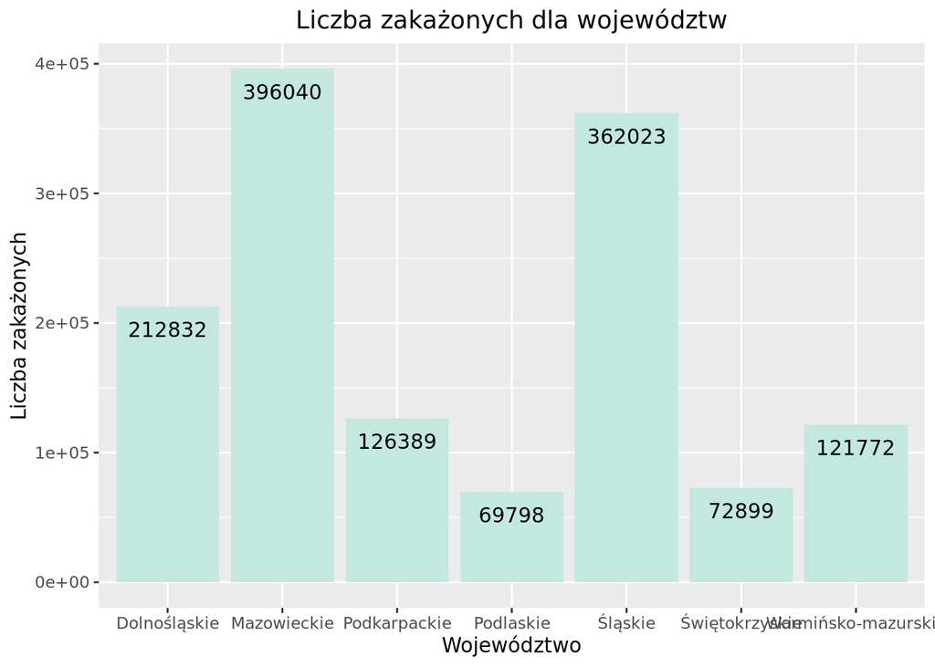

#### Stosunek liczby śmierci do zakażonych dla województw

```r
data_1['death_confirmed_cases_factor'] = data_1$deaths / data_1$confirmed_cases
```

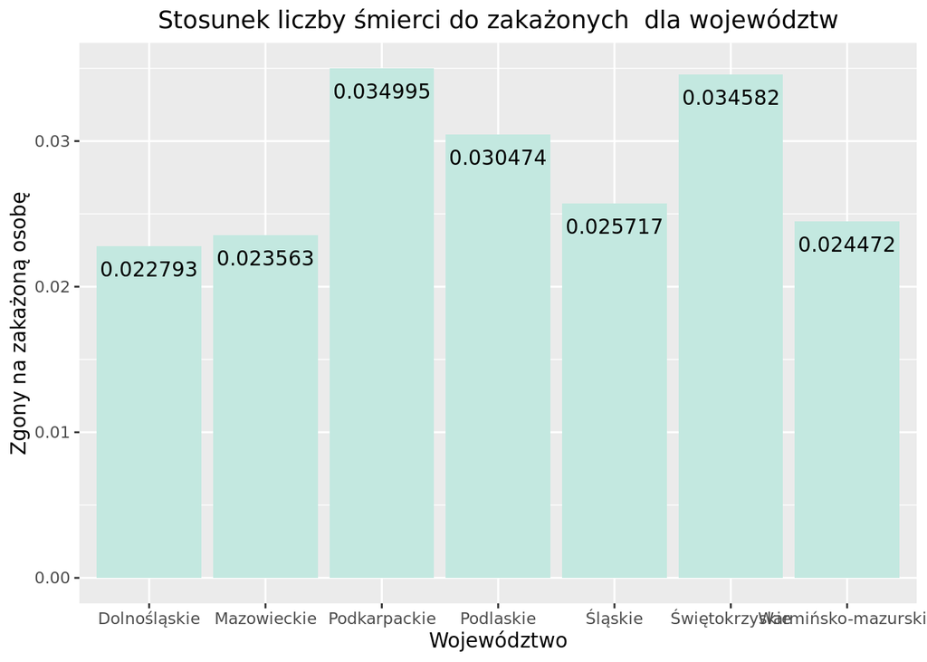

### Test zgodności rozkładu *chi-kwadrat*

```r
confirmed_cases_probabilities <- data_1$confirmed_cases / sum(data_1$confirmed_cases)

test_result_b <- chisq.test(x=data_1$deaths, p=confirmed_cases_probabilities)

test_result_b
```

```
##
##  Chi-squared test for given probabilities
##
## data:  data_1$deaths
## X-squared = 836.45, df = 6, p-value < 2.2e-16
```

**p-wartość: 0** (zaokraglona do 6 mijesc po przecinku)

Gdyby testy przeprowadzano na poziomie istotności $\alpha$ = 0.05, należałoby uznać, że liczba przypadków smiertelnych nie jest proporcjonalna do liczby osób zarazonych w poszczególnych województwach.

### Test zgodności rozkładu *chi-kwadrat* dla par województw

Wyniki testów dla wszystkich możliwych par województw przedstawiono w poniższej tabeli (wartości zostały zaokrąglone do 6 miejsc po przecinku).

```r
pairwise_result_b <- data.frame(voivodeship_1=character(), voivodeship_2=character(), xsq=double(), pval=double())

for (i in 1:(nrow(data_1) - 1)) {
  for (j in (i+1):nrow(data_1)) {
    v_1 <- data_1$voivodeship[i]
    v_2 <- data_1$voivodeship[j]
    ccp <- data_1$confirmed_cases[c(i, j)] / sum(data_1$confirmed_cases[c(i, j)])
    tr <- chisq.test(x=data_1$deaths[c(i, j)], p=ccp)
    pairwise_result_b <- pairwise_result_b %>% tibble::add_row(voivodeship_1=v_1,
                                                           voivodeship_2=v_2,
                                                           xsq=tr$statistic,
                                                           pval=tr$p.value)
  }
}
```

| Województwo (1) | Województwo (2) | X-squared | p-value |
| --- | --- | --- | --- |
| Mazowieckie | Warmińsko-mazurskie | 3.234350 | 0.072109 |
| Mazowieckie | Dolnośląskie | 3.529585 | 0.060283 |
| Mazowieckie | Podkarpackie | 475.577555 | 0.000000 |
| Mazowieckie | Podlaskie | 115.196340 | 0.000000 |
| Mazowieckie | Śląskie | 35.661576 | 0.000000 |
| Mazowieckie | Świętokrzyskie | 295.734674 | 0.000000 |
| Warmińsko-mazurskie | Dolnośląskie | 9.333484 | 0.002250 |
| Warmińsko-mazurskie | Podkarpackie | 230.219521 | 0.000000 |
| Warmińsko-mazurskie | Podlaskie | 59.947554 | 0.000000 |
| Warmińsko-mazurskie | Śląskie | 5.556677 | 0.018410 |
| Warmińsko-mazurskie | Świętokrzyskie | 164.945610 | 0.000000 |
| Dolnośląskie | Podkarpackie | 431.894207 | 0.000000 |
| Dolnośląskie | Podlaskie | 125.599400 | 0.000000 |
| Dolnośląskie | Śląskie | 46.518518 | 0.000000 |
| Dolnośląskie | Świętokrzyskie | 292.524049 | 0.000000 |
| Podkarpackie | Podlaskie | 27.534201 | 0.000000 |
| Podkarpackie | Śląskie | 286.839483 | 0.000000 |
| Podkarpackie | Świętokrzyskie | 0.226364 | 0.634233 |
| Podlaskie | Śląskie | 49.996921 | 0.000000 |
| Podlaskie | Świętokrzyskie | 18.477892 | 0.000017 |
| Śląskie | Świętokrzyskie | 175.324355 | 0.000000 |

# Zadanie 2